# Analysis of longitudinal data

Hoo boy. It’s the last week of IODS course, and this time we’re analyzing data that includes non-independent measurements (e.g. repeated measurements of a test subject over time). Let’s start with the libraries and data exploration!

```r
# Setup block
# Remove the '##' from each line of R output blocks
knitr::opts_chunk$set(comment = '')

# Libraries
library(dplyr)
library(ggplot2)
library(gridExtra)
library(stringr)
library(lme4)
library(reshape2)
```

This week’s assignment has a twist! We are going to repeat the examples from Vehkalahti and Everitt (2019) book *Multivariate Analysis for The Behavioral Sciences*, chapters 8 and 9, except with the data sets swapped between the chapters. I’ve wrangled the data to a “long table” format in the corresponding wrangling exercise. You can find the code [here](https://github.com/pkars/IODS-project/blob/master/data/meet_and_repeat.R).

So first we have the `rats` data introduced in Ch. 9. The authors describe the data as following:

*[W]e shall use some data from a nutrition study conducted in three groups of rats (Crowder and Hand, 1990). The three groups were put on different diets, and each animal’s body weight (grams) was recorded repeatedly (approximately weekly, except in week seven when two recordings were taken) over a 9-week period. The question of most interest is whether the growth profiles of the three groups differ.*

```r
rats <- read.csv("data/rats.csv")
rats$ID <- as.factor(rats$ID)
rats$Group <- as.factor(rats$Group)
str(rats)
```

```
'data.frame':   176 obs. of  5 variables:
 $ ID    : Factor w/ 16 levels "1","2","3","4",..: 1 2 3 4 5 6 7 8 9 10 ...
 $ Group : Factor w/ 3 levels "1","2","3": 1 1 1 1 1 1 1 1 2 2 ...
 $ WD    : chr  "WD1" "WD1" "WD1" "WD1" ...
 $ weight: int  240 225 245 260 255 260 275 245 410 405 ...
 $ time  : int  1 1 1 1 1 1 1 1 1 1 ...
```

```r
summary(rats)
```

```
       ID      Group       WD                weight           time
 1      : 11   1:88   Length:176         Min.   :225.0   Min.   : 1.00
 2      : 11   2:44   Class :character   1st Qu.:267.0   1st Qu.:15.00
 3      : 11   3:44   Mode  :character   Median :344.5   Median :36.00
 4      : 11                             Mean   :384.5   Mean   :33.55
 5      : 11                             3rd Qu.:511.2   3rd Qu.:50.00
 6      : 11                             Max.   :628.0   Max.   :64.00
 (Other):110
```

There are 16 rats in total, 8 in group 1, 4 in group 2 and 4 in group 3. Each rat has an unique ID. `time` column is the measurement day.

Next, we have the `bprs`data introduced in Ch. 8. The authors’ description follows:

*Table 8.1 taken from Davis (2002). Here 40 male subjects were randomly assigned to one of two treatment groups and each subject was rated on the brief psychiatric rating scale (BPRS) measured before treatment began (week 0) and then at weekly intervals for eight weeks. The BPRS assesses the level of 18 symptom constructs such as hostility, suspiciousness, hallucinations and grandiosity; each of these is rated from one (not present) to seven (extremely severe). The scale is used to evaluate patients suspected of having schizophrenia.*

```r
bprs <- read.csv("data/bprs.csv")
# Create ID column before factor conversion
# treatment "1" and subject "1" -> 101
# treatment "2" and subject "20" -> 220
bprs$ID <- as.factor(bprs$treatment * 100 + bprs$subject)
# Categorical integers to categories...
bprs$treatment <- as.factor(bprs$treatment)
bprs$subject <- as.factor(bprs$subject)
str(bprs)
```

```
'data.frame':   360 obs. of  6 variables:
 $ treatment: Factor w/ 2 levels "1","2": 1 1 1 1 1 1 1 1 1 1 ...
 $ subject  : Factor w/ 20 levels "1","2","3","4",..: 1 2 3 4 5 6 7 8 9 10 ...
 $ weeks    : chr  "week0" "week0" "week0" "week0" ...
 $ bprs     : int  42 58 54 55 72 48 71 30 41 57 ...
 $ week     : int  0 0 0 0 0 0 0 0 0 0 ...
 $ ID       : Factor w/ 40 levels "101","102","103",..: 1 2 3 4 5 6 7 8 9 10 ...
```

```r
summary(bprs)
```

```
 treatment    subject       weeks                bprs            week
 1:180     1      : 18   Length:360         Min.   :18.00   Min.   :0
 2:180     2      : 18   Class :character   1st Qu.:27.00   1st Qu.:2
           3      : 18   Mode  :character   Median :35.00   Median :4
           4      : 18                      Mean   :37.66   Mean   :4
           5      : 18                      3rd Qu.:43.00   3rd Qu.:6
           6      : 18                      Max.   :95.00   Max.   :8
           (Other):252
       ID
 101    :  9
 102    :  9
 103    :  9
 104    :  9
 105    :  9
 106    :  9
 (Other):306
```

```r
# Check that there are 40 unique ID values
unique(bprs$ID)
```

```
 [1] 101 102 103 104 105 106 107 108 109 110 111 112 113 114 115 116 117 118 119
[20] 120 201 202 203 204 205 206 207 208 209 210 211 212 213 214 215 216 217 218
[39] 219 220
40 Levels: 101 102 103 104 105 106 107 108 109 110 111 112 113 114 115 ... 220
```

So, that’s 40 subjects divided evenly into two groups. This time however, the subject IDs are not unique within the data. They are unique within the group, though. That will cause me some issues later on, because I suck at R so I’ve created unique ID column here. In hindsight, this should’ve been done at the data wrangling stage, though I don’t recall it being in the instructions.

## Working with RATS data

### Plot of the rats’ weights (Fig. 8.1).

So here is a graphical overview of the time series of rats’ weight development. Group 1 seems to consist of smaller rats than the other two groups. Also there is one huge rat in group 2, which will skew the mean value for that group.

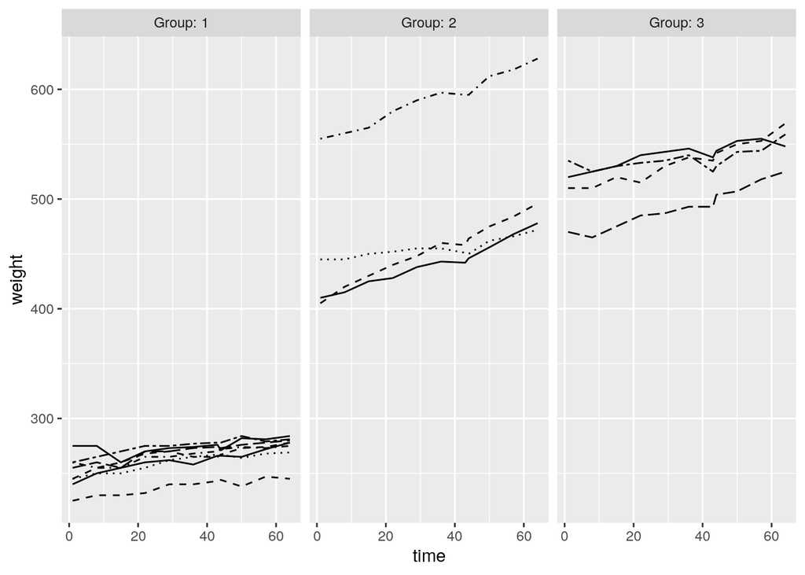

```r
ggplot(rats, aes(x = time, y = weight, linetype= ID)) +
  geom_line() +
  scale_linetype_manual(values = rep(1:8, 2)) +
  facet_grid(. ~ Group, labeller=label_both) +
  theme(legend.position = "none") +
  scale_y_continuous(limits = c(min(rats$weight), max(rats$weight)))
```

### Standardized weights (Fig 8.2)

Next up is “tracking”, i.e. plotting the time series of standardized weights. That’ll show how a rat gains weight compared to the others. This feels like anomaly detection in atmospheric dynamics, or de-trending. Though those things are a bit different – or at least the questions they try to answer are different. I think. Anyways, now the lines are not always increasing, so the relative development is easier to see.

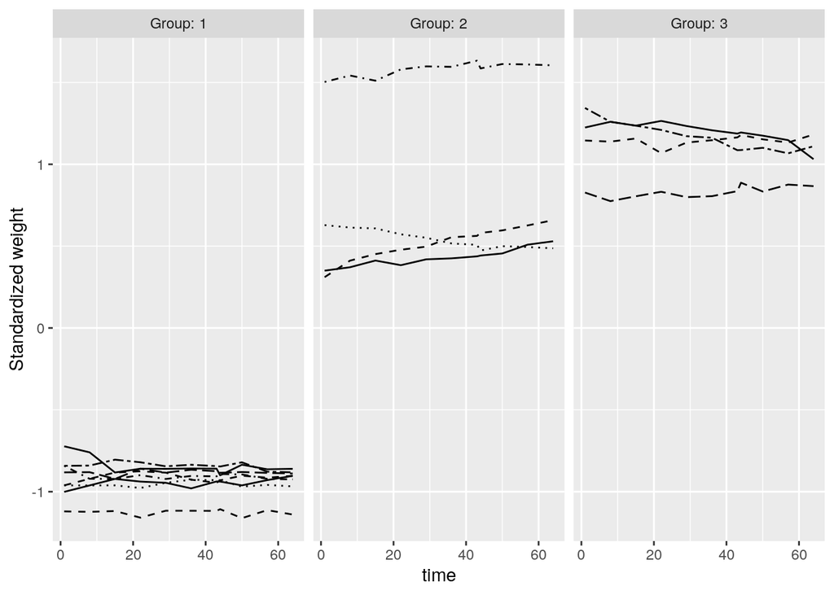

```r
rats_tracked <- rats %>%
  group_by(time) %>%
  mutate(std.weight = (weight - mean(weight))/sd(weight)) %>%
  ungroup()

ggplot(rats_tracked, aes(x = time, y = std.weight, linetype= ID)) +
  geom_line() +
  scale_linetype_manual(values = rep(1:8, 2)) +
  facet_grid(. ~ Group, labeller=label_both) +
  theme(legend.position = "none") +
  scale_y_continuous("Standardized weight")
```

### Mean response profiles (Fig. 8.3)

This is a way of visualising the overall development of the group and estimate the typical range of values for a given group and time. Also I noticed that in the course’s discussion page there was some talk about the standard error calculation. Namely that the denominator `sqrt(n)` was incorrectly presented in the Datacamp tutorials (`n` was the number of unique time instants there). So I opted to change the value to the number of members (rows) in a certain group at a certain time.

```r
ratss <- rats %>%
  group_by(Group, time) %>%
  summarise( mean = mean(weight), se = sd(weight)/sqrt(n()), .groups="keep") %>%
  ungroup()

# Glimpse the data
glimpse(ratss)
```

```
Rows: 33
Columns: 4
$ Group <fct> 1, 1, 1, 1, 1, 1, 1, 1, 1, 1, 1, 2, 2, 2, 2, 2, 2, 2, 2, 2, 2, …
$ time  <int> 1, 8, 15, 22, 29, 36, 43, 44, 50, 57, 64, 1, 8, 15, 22, 29, 36,…
$ mean  <dbl> 250.625, 255.000, 254.375, 261.875, 264.625, 265.000, 267.375, …
$ se    <dbl> 5.381640, 4.629100, 4.057346, 4.808614, 3.909409, 4.166190, 3.8…
```

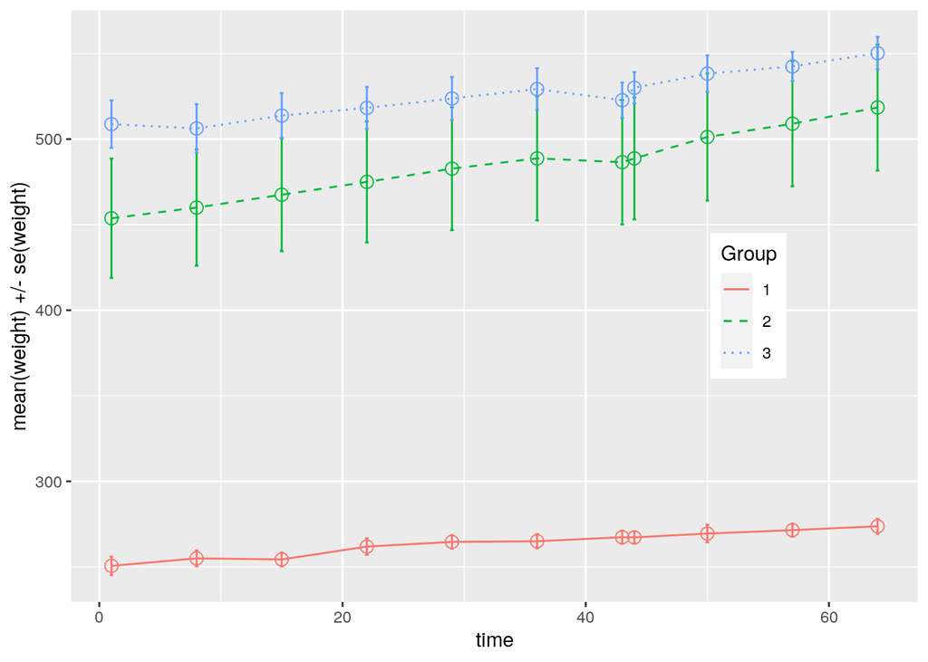

```r
# Plot the mean profiles
ggplot(ratss, aes(x = time, y = mean, linetype = Group, shape="1", color=Group)) +
  geom_line() +
  scale_linetype_manual(values = c(1,2,3)) +
  geom_point(size=3, show.legend = F) +
  scale_shape_manual(values = c(1,2,3)) +
  geom_errorbar(aes(ymin=mean-se, ymax=mean+se, linetype="1"), width=0.3) +
  theme(legend.position = c(0.8,0.5)) +
  scale_y_continuous(name = "mean(weight) +/- se(weight)")
```

### Boxplots for rats data (Fig. 8.4)

Next up is a boxplot. I think it shows about the same thing as the previous figure, but emphasis is on the quantiles (inter-quantile range etc.) instead of standard error. Of course, if the distributions are skewed, then the mean and median values differ: in the Group 2 the outlier rat has quite a pull to the mean value.

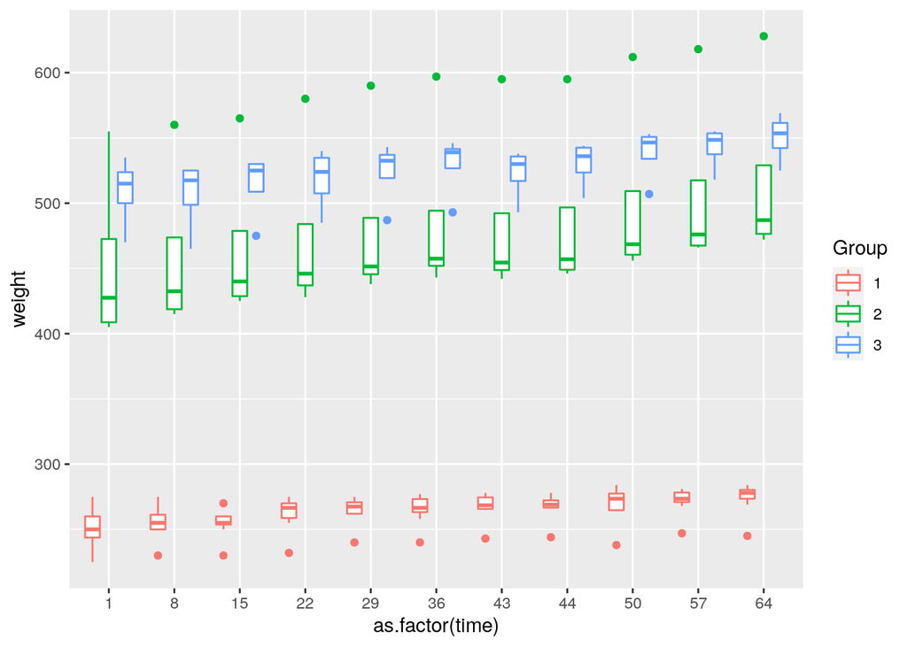

```r
ggplot(rats, aes(x=as.factor(time), y=weight, color=Group)) +
  geom_boxplot()
```

### Boxplots of mean summary measures for the three rat groups (Fig. 8.5)

This plot should tell me a quick overview about the differences between the groups. And if there are any outliers.

```r
# Create a summary data by treatment and subject with mean as the summary variable (ignoring baseline day 1).
rats_sm <- rats %>%
  filter(time > 1) %>%
  group_by(Group, ID) %>%
  summarise( mean=mean(weight), .groups="keep" ) %>%
  ungroup()

# Glimpse the data
glimpse(rats_sm)
```

```
Rows: 16
Columns: 3
$ Group <fct> 1, 1, 1, 1, 1, 1, 1, 1, 2, 2, 2, 2, 3, 3, 3, 3
$ ID    <fct> 1, 2, 3, 4, 5, 6, 7, 8, 9, 10, 11, 12, 13, 14, 15, 16
$ mean  <dbl> 263.2, 238.9, 261.7, 267.2, 270.9, 276.2, 274.6, 267.5, 443.9, …
```

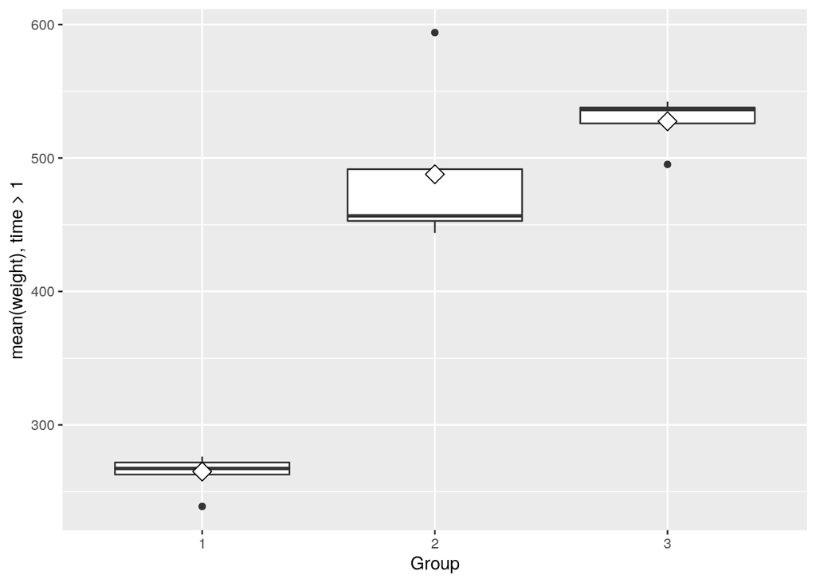

```r
# Draw a boxplot of the mean versus treatment
ggplot(rats_sm, aes(x = Group, y = mean)) +
  geom_boxplot() +
  stat_summary(fun = "mean", geom = "point", shape=23, size=4, fill = "white") +
  scale_y_continuous(name = "mean(weight), time > 1")
```

### Same as above but with outliers (if any) removed (Fig. 8.6)

Okay so, group 2 has an outlier. Remove it. Though I’m removing 1 rat from a total 4 rats, meaning that the statistics start to be *quite* dubious… `n=3` doesn’t sound like a large enough of a sample.

```r
# Create a new data by filtering the outlier and adjust the ggplot code the draw the plot again with the new data
rats_sm1 <-  rats_sm %>% filter(mean < 575)
glimpse(rats_sm1)
```

```
Rows: 15
Columns: 3
$ Group <fct> 1, 1, 1, 1, 1, 1, 1, 1, 2, 2, 2, 3, 3, 3, 3
$ ID    <fct> 1, 2, 3, 4, 5, 6, 7, 8, 9, 10, 11, 13, 14, 15, 16
$ mean  <dbl> 263.2, 238.9, 261.7, 267.2, 270.9, 276.2, 274.6, 267.5, 443.9, …
```

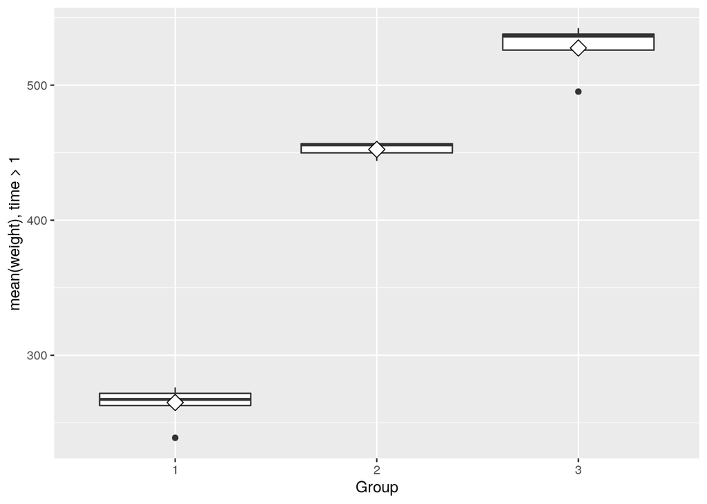

```r
ggplot(rats_sm1, aes(x = Group, y = mean)) +
  geom_boxplot() +
  stat_summary(fun = "mean", geom = "point", shape=23, size=4, fill = "white") +
  scale_y_continuous(name = "mean(weight), time > 1")
```

### *t*-test for Mean Summary Measure (table 8.3)

*t*-test is a paired test, so there can be only two variables. Luckily three groups equate to three pairs, so I can do the t-test for each pair with minimal effort (copypaste). Based on the results it is very clear that the Group 1 differs from Groups 2 and 3. Between the groups 2 and 3 the difference is not as clear, but it’s there.

```r
rats_sm1_noG3 <- rats_sm1 %>% filter(Group != 3)
t.test(mean ~ Group, data = rats_sm1_noG3, var.equal = TRUE)
```

```
    Two Sample t-test

data:  mean by Group
t = -25.399, df = 9, p-value = 1.094e-09
alternative hypothesis: true difference in means is not equal to 0
95 percent confidence interval:
 -204.0633 -170.6867
sample estimates:
mean in group 1 mean in group 2
        265.025         452.400
```

```r
rats_sm1_noG2 <- rats_sm1 %>% filter(Group != 2)
t.test(mean ~ Group, data = rats_sm1_noG2, var.equal = TRUE)
```

```
    Two Sample t-test

data:  mean by Group
t = -27.824, df = 10, p-value = 8.345e-11
alternative hypothesis: true difference in means is not equal to 0
95 percent confidence interval:
 -283.4943 -241.4557
sample estimates:
mean in group 1 mean in group 3
        265.025         527.500
```

```r
rats_sm1_noG1 <- rats_sm1 %>% filter(Group != 1)
t.test(mean ~ Group, data = rats_sm1_noG1, var.equal = TRUE)
```

```
    Two Sample t-test

data:  mean by Group
t = -5.632, df = 5, p-value = 0.002446
alternative hypothesis: true difference in means is not equal to 0
95 percent confidence interval:
 -109.37769  -40.82231
sample estimates:
mean in group 2 mean in group 3
          452.4           527.5
```

### Analysis of Covariance (ANOVA) (table 8.4)

For the ANOVA I need a baseline for each row – and that is easy to pick up from the original data. This works because the `rats_sm` contains only one row for each rat – it is a summary of all measurements – and the original data has one row for each rat, too. If it weren’t for the summarized data, I’d have to join by ID columns. Although that would be clearer than this, but (probably) slower…

```r
original_rats <- read.csv("https://raw.githubusercontent.com/KimmoVehkalahti/MABS/master/Examples/data/rats.txt",
                          header=TRUE, sep="\t")
rats_sm2 <- rats_sm %>%
  mutate(baseline = original_rats$WD1)

fit <- lm(mean ~ baseline + Group, data = rats_sm2)
anova(fit)
```

```
Analysis of Variance Table

Response: mean
          Df Sum Sq Mean Sq   F value   Pr(>F)
baseline   1 253625  253625 1859.8201 1.57e-14 ***
Group      2    879     439    3.2219  0.07586 .
Residuals 12   1636     136
---
Signif. codes:  0 '***' 0.001 '**' 0.01 '*' 0.05 '.' 0.1 ' ' 1
```

So the interpretation for this set. Baseline (=starting weight) is significant contributor to the later weight. Belonging to a certain group has some significance, probably whether the rat belongs to the Group 1 or not.

Lastly, I’m omitting the Table 8.6. It doesn’t use the BPRS data in the original, so strictly speaking cannot swap that data to RATS dataset. It also demonstrates how to deal with missing data, so performing the analysis with a full dataset is not the most productive way (of course I could randomly remove some of the data and work that way, but I’m being lazy here).

## Working with BPRS data

Moving on to the BPRS data and Chapter 9 examples. I might take some liberties here and there in visualising the data instead of 100% faithfully replicating the figures. Mainly because the data is different so I might need to adjust the visuals a bit to increase readability.

### Week vs BPRS with group numbers (Fig. 9.1)

Here the two groups overlap more than the rats, and we have more individuals here as well!

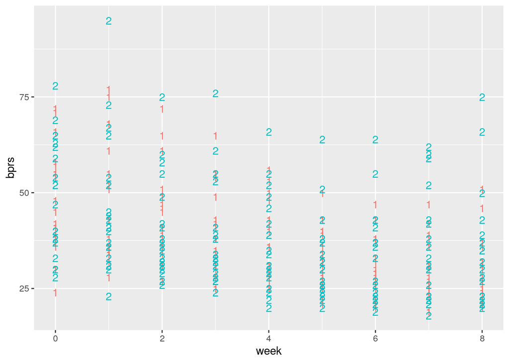

```r
ggplot(bprs, aes(x=week, y=bprs, color=treatment)) +
  geom_text(aes(label=treatment), show.legend=FALSE)
```

### Results from fitting linear reg.model ignoring the repeated-measures structure of the data (Table 9.3)

These results should be total nonsense. Spoilers: they are. The results “show” that the time dimension has a really strong effect on the measures. Well yeah, about that independence… The linear regression is assuming independent measures, i.e. no autocorrelation or codependency. Shame it is totally untrue when one measures the same subject(s) over time…

```r
# create a regression model RATS_reg
bprs_reg <- lm(bprs ~ week + treatment, data = bprs)
# print out a summary of the model
summary(bprs_reg)
```

```
Call:
lm(formula = bprs ~ week + treatment, data = bprs)

Residuals:
    Min      1Q  Median      3Q     Max
-22.454  -8.965  -3.196   7.002  50.244

Coefficients:
            Estimate Std. Error t value Pr(>|t|)
(Intercept)  46.4539     1.3670  33.982   <2e-16 ***
week         -2.2704     0.2524  -8.995   <2e-16 ***
treatment2    0.5722     1.3034   0.439    0.661
---
Signif. codes:  0 '***' 0.001 '**' 0.01 '*' 0.05 '.' 0.1 ' ' 1

Residual standard error: 12.37 on 357 degrees of freedom
Multiple R-squared:  0.1851,    Adjusted R-squared:  0.1806
F-statistic: 40.55 on 2 and 357 DF,  p-value: < 2.2e-16
```

Don’t tell anyone, but I’m going to cheat a bit here and plot an extra figure or two. Because I want to see how this faulty analysis looks like!

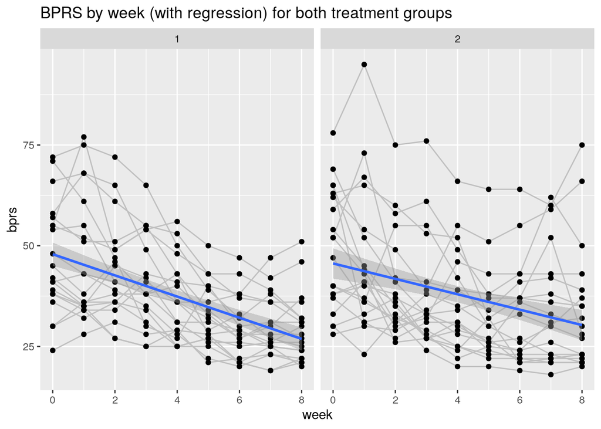

```r
fit <- fitted(bprs_reg, bprs)

ggplot(bprs, aes(x=week, y=bprs)) +
  geom_line(aes(group=subject), color="gray75") +
  geom_point() +
  geom_smooth(method="lm") +
  labs(title="BPRS by week (with regression) for both treatment groups") +
  facet_wrap(vars(treatment))
```

Since the `treatment` is a categorical value, I can plot the linear regression this way. It helps that there are two categories in `treatment`, though. I included the the time series as lines, too, to highlight why this sort of regression modeling doesn’t work here. Okay, sure, it shows the downward trend in both groups, but for analysing trends you’d want to consider the “repeated measures” nature of the data anyways[^1].

### Individual BTRS profiles (Fig. 9.2)

Here’s where the custom `ID` column comes in handy. I need to be able to differentiate between the subjects with the same `subject` value but different `treatment` value. Otherwise this plot would become confused, poor thing.

```r
# Check that the ID column is included
str(bprs)
```

```
'data.frame':   360 obs. of  6 variables:
 $ treatment: Factor w/ 2 levels "1","2": 1 1 1 1 1 1 1 1 1 1 ...
 $ subject  : Factor w/ 20 levels "1","2","3","4",..: 1 2 3 4 5 6 7 8 9 10 ...
 $ weeks    : chr  "week0" "week0" "week0" "week0" ...
 $ bprs     : int  42 58 54 55 72 48 71 30 41 57 ...
 $ week     : int  0 0 0 0 0 0 0 0 0 0 ...
 $ ID       : Factor w/ 40 levels "101","102","103",..: 1 2 3 4 5 6 7 8 9 10 ...
```

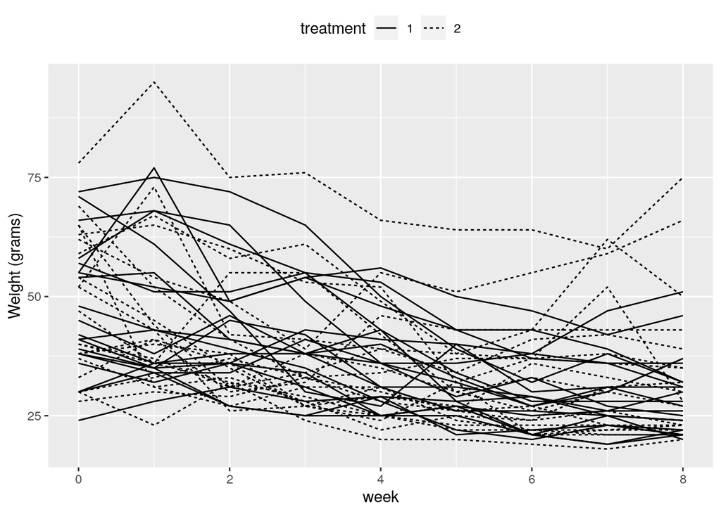

```r
ggplot(bprs, aes(x = week, y = bprs, group=ID)) +
  geom_line(aes(linetype=treatment)) +
  scale_y_continuous(name = "Weight (grams)") +
  theme(legend.position = "top")
```

### Scatterplot matrix of repeated measures (Fig. 9.3)

This thing requires the original data. Maybe I could pivot the data… Yep, that works. Yes, the scatters form rather nice lines, especially between two consecutive weeks.

```r
bprs_w <- tidyr::pivot_wider(bprs, names_from=weeks, values_from=bprs,
                             id_cols=c("treatment", "subject", "ID")) %>%
  as.data.frame
str(bprs_w)
```

```
'data.frame':   40 obs. of  12 variables:
 $ treatment: Factor w/ 2 levels "1","2": 1 1 1 1 1 1 1 1 1 1 ...
 $ subject  : Factor w/ 20 levels "1","2","3","4",..: 1 2 3 4 5 6 7 8 9 10 ...
 $ ID       : Factor w/ 40 levels "101","102","103",..: 1 2 3 4 5 6 7 8 9 10 ...
 $ week0    : int  42 58 54 55 72 48 71 30 41 57 ...
 $ week1    : int  36 68 55 77 75 43 61 36 43 51 ...
 $ week2    : int  36 61 41 49 72 41 47 38 39 51 ...
 $ week3    : int  43 55 38 54 65 38 30 38 35 55 ...
 $ week4    : int  41 43 43 56 50 36 27 31 28 53 ...
 $ week5    : int  40 34 28 50 39 29 40 26 22 43 ...
 $ week6    : int  38 28 29 47 32 33 30 26 20 43 ...
 $ week7    : int  47 28 25 42 38 27 31 25 23 39 ...
 $ week8    : int  51 28 24 46 32 25 31 24 21 32 ...
```

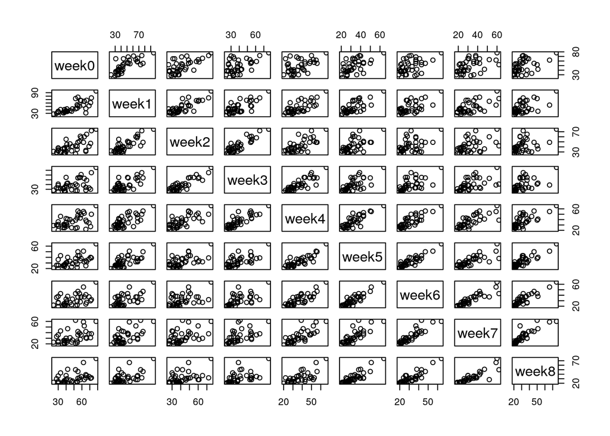

```r
plot(bprs_w[-1:-3])
```

### Results from fitting random intercept model (Table 9.4)

But now we will loosen the requirement of totally independent measures. First the random intercept allows the fit differ between the individuals.

```r
# Create a random intercept model
bprs_ref <- lmer(bprs ~ week + treatment + (1 | subject), data = bprs, REML = FALSE)

# Print the summary of the model
summary(bprs_ref)
```

```
Linear mixed model fit by maximum likelihood  ['lmerMod']
Formula: bprs ~ week + treatment + (1 | subject)
   Data: bprs

     AIC      BIC   logLik deviance df.resid
  2748.7   2768.1  -1369.4   2738.7      355

Scaled residuals:
    Min      1Q  Median      3Q     Max
-3.0481 -0.6749 -0.1361  0.4813  3.4855

Random effects:
 Groups   Name        Variance Std.Dev.
 subject  (Intercept)  47.41    6.885
 Residual             104.21   10.208
Number of obs: 360, groups:  subject, 20

Fixed effects:
            Estimate Std. Error t value
(Intercept)  46.4539     1.9090  24.334
week         -2.2704     0.2084 -10.896
treatment2    0.5722     1.0761   0.532

Correlation of Fixed Effects:
           (Intr) week
week       -0.437
treatment2 -0.282  0.000
```

### Results from fitting random intercept and slope model (Table 9.5)

Next, let’s introduce the random *slope* to the model. And the winning numbers are… Huh? Not much of a change.

```r
# create a random intercept and random slope model
bprs_ref1 <- lmer(bprs ~ week + treatment + (week | subject), data = bprs, REML = FALSE)

# print a summary of the model
summary(bprs_ref1)
```

```
Linear mixed model fit by maximum likelihood  ['lmerMod']
Formula: bprs ~ week + treatment + (week | subject)
   Data: bprs

     AIC      BIC   logLik deviance df.resid
  2745.4   2772.6  -1365.7   2731.4      353

Scaled residuals:
    Min      1Q  Median      3Q     Max
-2.8919 -0.6194 -0.0691  0.5531  3.7976

Random effects:
 Groups   Name        Variance Std.Dev. Corr
 subject  (Intercept) 64.8222  8.0512
          week         0.9609  0.9802   -0.51
 Residual             97.4305  9.8707
Number of obs: 360, groups:  subject, 20

Fixed effects:
            Estimate Std. Error t value
(Intercept)  46.4539     2.1052  22.066
week         -2.2704     0.2977  -7.626
treatment2    0.5722     1.0405   0.550

Correlation of Fixed Effects:
           (Intr) week
week       -0.582
treatment2 -0.247  0.000
```

```r
# perform an ANOVA test on the two models
anova(bprs_ref1, bprs_ref)
```

```
Data: bprs
Models:
bprs_ref: bprs ~ week + treatment + (1 | subject)
bprs_ref1: bprs ~ week + treatment + (week | subject)
          npar    AIC    BIC  logLik deviance  Chisq Df Pr(>Chisq)
bprs_ref     5 2748.7 2768.1 -1369.4   2738.7
bprs_ref1    7 2745.4 2772.6 -1365.7   2731.4 7.2721  2    0.02636 *
---
Signif. codes:  0 '***' 0.001 '**' 0.01 '*' 0.05 '.' 0.1 ' ' 1
```

So, knowing there are duplicate values in `subject` column, I’m not so sure if that fitting did what we wanted to do here. Let’s do this again using `ID` instead of `subject`.

```r
# Create a random intercept model
bprs_ref_id <- lmer(bprs ~ week + treatment + (1 | ID), data = bprs, REML = FALSE)

# Print the summary of the model
summary(bprs_ref_id)
```

```
Linear mixed model fit by maximum likelihood  ['lmerMod']
Formula: bprs ~ week + treatment + (1 | ID)
   Data: bprs

     AIC      BIC   logLik deviance df.resid
  2582.9   2602.3  -1286.5   2572.9      355

Scaled residuals:
     Min       1Q   Median       3Q      Max
-2.27506 -0.59909 -0.06104  0.44226  3.15835

Random effects:
 Groups   Name        Variance Std.Dev.
 ID       (Intercept) 97.39    9.869
 Residual             54.23    7.364
Number of obs: 360, groups:  ID, 40

Fixed effects:
            Estimate Std. Error t value
(Intercept)  46.4539     2.3521  19.750
week         -2.2704     0.1503 -15.104
treatment2    0.5722     3.2159   0.178

Correlation of Fixed Effects:
           (Intr) week
week       -0.256
treatment2 -0.684  0.000
```

```r
# create a random intercept and random slope model
bprs_ref_id1 <- lmer(bprs ~ week + treatment + (week | ID), data = bprs, REML = FALSE)

# print a summary of the model
summary(bprs_ref_id1)
```

[output not shown]

```r
# perform an ANOVA test on the two models
anova(bprs_ref_id1, bprs_ref_id)
```

```
Data: bprs
Models:
bprs_ref_id: bprs ~ week + treatment + (1 | ID)
bprs_ref_id1: bprs ~ week + treatment + (week | ID)
             npar    AIC    BIC  logLik deviance  Chisq Df Pr(>Chisq)
bprs_ref_id     5 2582.9 2602.3 -1286.5   2572.9
bprs_ref_id1    7 2523.2 2550.4 -1254.6   2509.2 63.663  2  1.499e-14 ***
---
Signif. codes:  0 '***' 0.001 '**' 0.01 '*' 0.05 '.' 0.1 ' ' 1
```

Well look at that! Using `ID` instead of `subject` made quite a difference! While the previous ANOVA result had “only” one star of significance for the random intercept and slope model, this one here has *three* stars!

… I have no idea what’s going on here. The baseline got really important? Or that I cut the sample size down by telling the model “hey there are 40 dudes instead of 20”? I mean, the sample size for each individual fit, that is. Let me ask a question…

```r
# perform an ANOVA test on the two models
anova(bprs_ref_id1, bprs_ref1)
```

```
Data: bprs
Models:
bprs_ref_id1: bprs ~ week + treatment + (week | ID)
bprs_ref1: bprs ~ week + treatment + (week | subject)
             npar    AIC    BIC  logLik deviance Chisq Df Pr(>Chisq)
bprs_ref_id1    7 2523.2 2550.4 -1254.6   2509.2
bprs_ref1       7 2745.4 2772.6 -1365.7   2731.4     0  0
```

### Fitting the random intercept and slope model with Subject×Week interaction (Table 9.6)

Then there is a third way of building a model: we allow an interaction between the two variables. Notice the `*` (star) instead of `+` (plus) symbol in the model definition!

```r
# create a random intercept and random slope model with the interaction
bprs_ref2 <- lmer(bprs ~ week * treatment + (week | subject), data = bprs, REML = FALSE)

# print a summary of the model
summary(bprs_ref2)
```

```
Linear mixed model fit by maximum likelihood  ['lmerMod']
Formula: bprs ~ week * treatment + (week | subject)
   Data: bprs

     AIC      BIC   logLik deviance df.resid
  2744.3   2775.4  -1364.1   2728.3      352

Scaled residuals:
    Min      1Q  Median      3Q     Max
-3.0512 -0.6271 -0.0768  0.5288  3.9260

Random effects:
 Groups   Name        Variance Std.Dev. Corr
 subject  (Intercept) 64.9964  8.0620
          week         0.9687  0.9842   -0.51
 Residual             96.4707  9.8220
Number of obs: 360, groups:  subject, 20

Fixed effects:
                Estimate Std. Error t value
(Intercept)      47.8856     2.2521  21.262
week             -2.6283     0.3589  -7.323
treatment2       -2.2911     1.9090  -1.200
week:treatment2   0.7158     0.4010   1.785

Correlation of Fixed Effects:
            (Intr) week   trtmn2
week        -0.650
treatment2  -0.424  0.469
wek:trtmnt2  0.356 -0.559 -0.840
```

```r
# perform an ANOVA test on the two models
anova(bprs_ref2, bprs_ref1)
```

```
Data: bprs
Models:
bprs_ref1: bprs ~ week + treatment + (week | subject)
bprs_ref2: bprs ~ week * treatment + (week | subject)
          npar    AIC    BIC  logLik deviance  Chisq Df Pr(>Chisq)
bprs_ref1    7 2745.4 2772.6 -1365.7   2731.4
bprs_ref2    8 2744.3 2775.4 -1364.1   2728.3 3.1712  1    0.07495 .
---
Signif. codes:  0 '***' 0.001 '**' 0.01 '*' 0.05 '.' 0.1 ' ' 1
```

So looks like that change might bring a little bit more prediction power to the model. Or at least the models’ difference has a bit of significance. Let’s do the same with `ID` this time.

```r
# create a random intercept and random slope model with the interaction
bprs_ref_id2 <- lmer(bprs ~ week * treatment + (week | ID), data = bprs, REML = FALSE)

# print a summary of the model
summary(bprs_ref_id2)
```

```
Linear mixed model fit by maximum likelihood  ['lmerMod']
Formula: bprs ~ week * treatment + (week | ID)
   Data: bprs

     AIC      BIC   logLik deviance df.resid
  2523.5   2554.5  -1253.7   2507.5      352

Scaled residuals:
    Min      1Q  Median      3Q     Max
-2.4747 -0.5256 -0.0866  0.4435  3.7884

Random effects:
 Groups   Name        Variance Std.Dev. Corr
 ID       (Intercept) 164.204  12.814
          week          2.203   1.484   -0.66
 Residual              36.748   6.062
Number of obs: 360, groups:  ID, 40

Fixed effects:
                Estimate Std. Error t value
(Intercept)      47.8856     2.9840  16.047
week             -2.6283     0.3752  -7.006
treatment2       -2.2911     4.2200  -0.543
week:treatment2   0.7158     0.5306   1.349

Correlation of Fixed Effects:
            (Intr) week   trtmn2
week        -0.668
treatment2  -0.707  0.473
wek:trtmnt2  0.473 -0.707 -0.668
```

```r
# perform an ANOVA test on the two models
anova(bprs_ref_id2, bprs_ref_id1)
```

```
Data: bprs
Models:
bprs_ref_id1: bprs ~ week + treatment + (week | ID)
bprs_ref_id2: bprs ~ week * treatment + (week | ID)
             npar    AIC    BIC  logLik deviance Chisq Df Pr(>Chisq)
bprs_ref_id1    7 2523.2 2550.4 -1254.6   2509.2
bprs_ref_id2    8 2523.5 2554.6 -1253.7   2507.5  1.78  1     0.1821
```

Well. Maybe the model overfits here and thus I don’t have enough variance that could vary between the two models? Let’s see how the `subject` versus `ID` question works out.

```r
anova(bprs_ref_id2, bprs_ref2)
```

```
Data: bprs
Models:
bprs_ref_id2: bprs ~ week * treatment + (week | ID)
bprs_ref2: bprs ~ week * treatment + (week | subject)
             npar    AIC    BIC  logLik deviance Chisq Df Pr(>Chisq)
bprs_ref_id2    8 2523.5 2554.6 -1253.7   2507.5
bprs_ref2       8 2744.3 2775.4 -1364.1   2728.3     0  0
```

Zero degrees of freedom. Yeah, that’s a dead end.

### Fitted and observed growth profiles (Figure 9.4)

Finally, there was a plot side-by-side showing original and fitted lines. Well, here you go dear reader! As the authors of MABS said, the regression lines fit quite nicely to the original data. Granted, the BPRS measures had more variance than the rats, but overall the figures are in agreement. Notably, the rats’ weight was more or less monotonically increasing, while BPRS goes up-and-down (the main trend is downwards for most of the individuals, though).

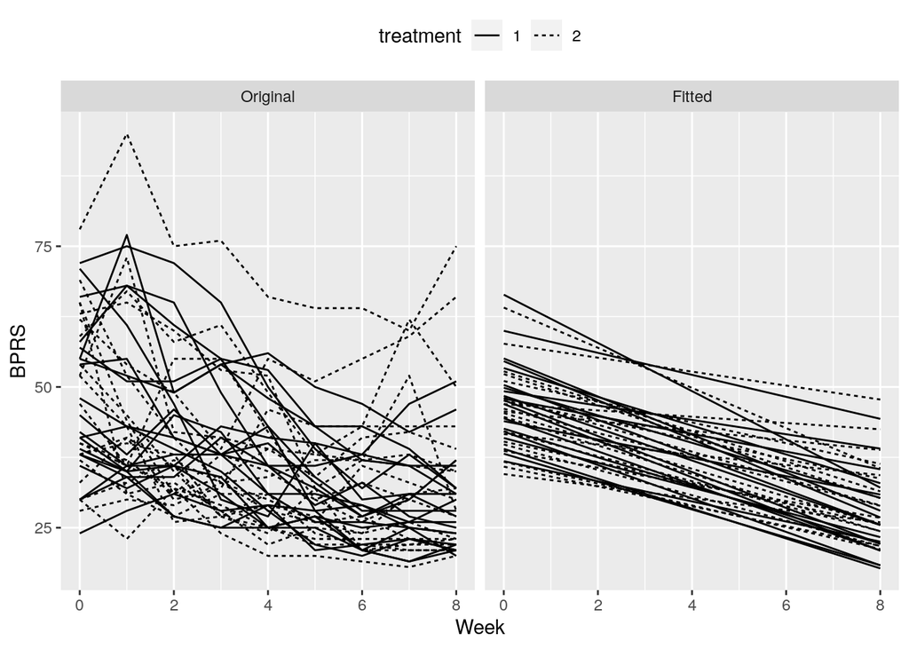

```r
# Create a vector of the fitted values
# Making a copy so I won't accidentally use this data somewhere else :)
bprs2 <- bprs
bprs2$Fitted <- fitted(bprs_ref2, bprs)
# Rename original "bprs" column for visualisation purposes
colnames(bprs2)[4] <- "Original"

# Melting data to "melted" (which is probably grammatically incorrect form of 'melt')
melted <- melt(bprs2,
               id.vars=c("treatment","subject","ID", "week"),
               measure.vars=c("Original", "Fitted"),
               variable.name = "key",
               value.name = "BPRS")

ggplot(melted, aes(x=week, y=BPRS, group=ID)) +
  geom_line(aes(linetype=treatment)) +
  facet_wrap(vars(key)) +
  theme(legend.position="top") +
  xlab("Week")
```

[^1]: I’m having trouble imagining what sort of measures would be time series measures *and simultaneously not repeated* measures, as “time series” already implies repetition. Perhaps sequences of truly random noise, such as atmospheric noise, could be considered as such measure?